# ME323 - Introdução aos Modelos Probabilísticos

## Variáveis Aleatórias Contínuas

## Variáveis Aleatórias Contínuas

- **Variáveis aleatórias discretas:** v.a. com valores possíveis enumeráveis. Soma das probabilidades de todos os valores possíveis igual a \(1\).
- **Variáveis aleatórias contínuas:** v.a. com valores possíveis em um intervalo no conjunto de números reais.
- Exemplo: tempo para finalizar um experimento, peso de uma pessoa, duração de uma chamada telefônica, tempo de vida de uma lâmpada, etc…
- Para esses tipos de quantidades, não é possível associar frequências pontuais tais que a soma de todas seja igual a 1.
- Surge então o conceito de **"função de densidade de probabilidade"** (f.d.p.).
- Para cada v.a. contínua, associamos uma função de densidade de probabilidade.

## Exemplo: v.a. discreta

Distribuição de probabilidade de uma \(Bin(10, p)\), com \(p=0.2, 0.5\) e \(0.8\).

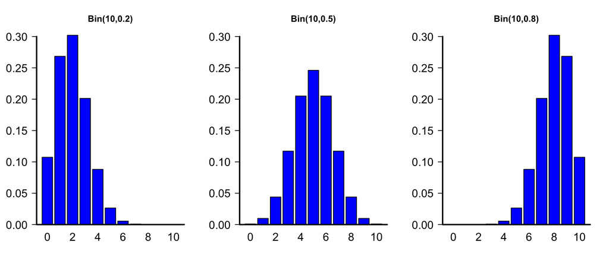

## Exemplo: v.a. discreta

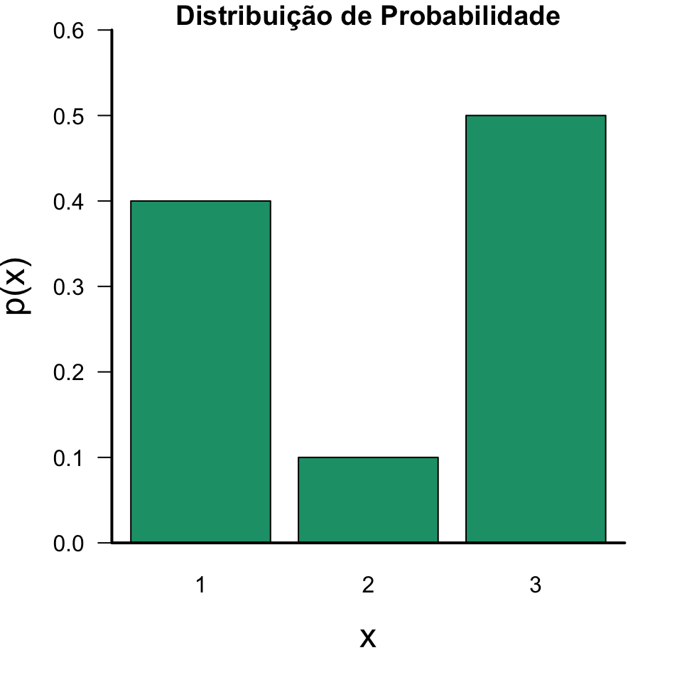

## Exemplo: v.a. contínua

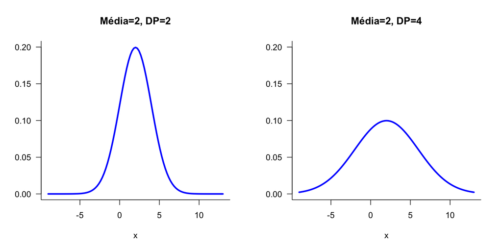

## Variáveis Aleatórias Contínuas

**Definição:** a função de densidade de probabilidade de uma v.a. \(X\) é uma função \(f\) que verifica:

- \(f(x)\geq0, \quad \forall x\in \mathbb{R}\)
- \(\displaystyle \int_{-\infty}^{\infty}f(x)dx=1\) (\(f\) é integrável)

> Toda v.a. \(X\) à qual seja possível associar uma função de densidade de probabilidade será chamada de v.a. contínua.

## Variáveis Aleatórias Contínuas

A probabilidade de que uma v.a. \(X\) contínua pertença a um intervalo da reta (a,b], \(a<b\) é dada por:  
\[P(a<X\leq b)=\int_{a}^{b}f(x)dx.\]

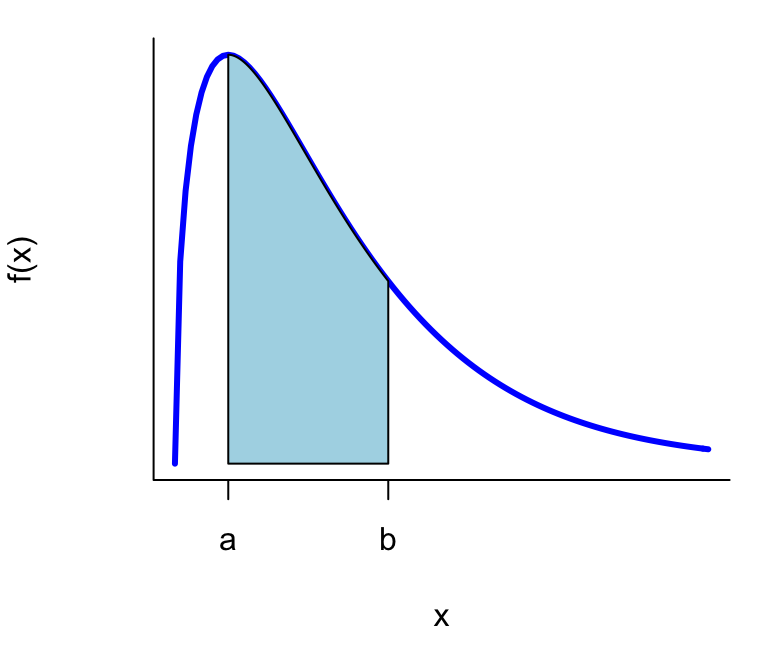

Obs: Quando \(X\) é v.a. contínua \(P(a<X\leq b)=P(a\leq X\leq b)=P(a<X< b)=P(a\leq X <b)\)

## Variáveis Aleatórias Contínuas

**Notação:** se \(X\) v.a. contínua com função de densidade de probabilidade \(f\), no lugar de \(f\) denotaremos \(f_{X}\).

> A probabilidade de que uma v.a. \(X\) contínua pertença ao intervalo da reta  
> (\(-\infty,x\)] daremos o nome de **função de distribuição acumulada** (f.d.a.), e a denotaremos por \(F_{X}\) \[F_{X}(x) = \int_{-\infty}^{x}f(u)du = P(X\leq x).\]

## Variáveis Aleatórias Contínuas

Exemplo: \(X\) v.a. contínua com função de densidade:

\[ f_{X}(x) = \left\{ \begin{array}{ll} x, & 0\leq x < 1 \\ 2-x, & 1 \leq x \leq 2 \\ 0, & \mbox{caso contrário} \\ \end{array} \right.\]

> Pela definição de função de densidade:

> \(f(x) \geq 0, \quad \forall \, x \in \mathbb R\)

> \(\displaystyle \int_{0}^{2}f(x)dx= \int_{0}^{1}xdx + \int_{1}^{2}(2-x)dx =1\)

> Podemos também calcular \(\displaystyle P(0<X\leq 0.8) = \int_{0}^{0.8}xdx=0.32\)

## Variáveis Aleatórias Contínuas

**Propriedade:** toda v.a. \(X\) contínua (ou seja, que possui \(f_{X}\) como função de densidade) tem probabilidade pontual nula: \(\, P(X=x)=0\).

A função de distribuição acumulada \(F(x)=P(X\leq x)\):

- **caso discreto:** \[F(x)=P(X \leq x)=\sum_{x_{i}\leq x}P(X=x_{i})\]
- **caso contínuo:** \[F(x)=P(X \leq x)=\int_{-\infty}^{x}f_{X}(u)du\]

## Exemplo

Dada a função

\[ f(x) = \left\{ \begin{array}{rcl} 0 & \mbox{se} & x < 0\\ 2e^{-2x} & \mbox{se} & x \geq 0 \\ \end{array} \right. \]

1. Mostre que esta é uma função de densidade de probabilidade.
2. Calcule a probabilidade de \(X>10\).

*Fonte: Morettin & Bussab*, Estatística Básica \(5^a\) edição, pág 166.

## Exemplo (solução - item 1)

Uma função de densidade de probabilidade deve satisfazer as seguintes propriedades:

1. \(f(x)\geq0\) para todo \(x \in \mathbb{R}\).
2. \(\displaystyle \int_{-\infty}^{\infty} f(x) dx = 1\).

> Note que \(e^{-x}\) é positiva para qualquer \(x\) e, consequentemente, \(2e^{-2x}\) também.

> Resta mostrar que sua integral é 1:

\[ \int 2e^{-2x} dx = -e^{-2x}\]

## Exemplo (solução)

1. Note que a função está definida nesta forma para \(x \geq 0\); para \(x<0\), ela é 0.

   Então a integral é:

   \[\begin{aligned} \int_{-\infty}^{\infty} f(x) dx &= \int_{-\infty}^0 0 dx + \int_0^{\infty} 2e^{-2x} dx \\ &= \left [ -e^{-2x} \right ] _{0}^{\infty} \\ &= \lim_{x\rightarrow \infty} -e^{-2x} - \left ( -e^{-0} \right) = 1 \end{aligned}\]
2. A probabilidade é dada por: \[P(X>10) = \int_{10}^{\infty} 2e^{-2x} dx = \lim_{x\rightarrow \infty} -e^{-2x} - \left ( -e^{-2 \times 10} \right) = \frac{1}{e^{20}}\]

## Esperança

**Definição:** seja \(X\) uma v.a. contínua com densidade \(f_{X}\), a **esperança** de \(X\) é dada por: \[\mathbb E(X) = \int_{-\infty}^{\infty}x \, f_{X}(x)dx \,.\]

> **Definição:** seja \(X\) uma v.a. contínua com densidade \(f_{X}\), o **\(k\)-ésimo momento** de \(X\) é dado por:

\[\mathbb E(X^k) = \int_{-\infty}^{\infty}x^k \, f_{X}(x)dx \,.\]

## Variância

**Definição:** seja \(X\) v.a. com valor esperado \(\mathbb E(X)\), definimos por **variância**, a quantidade:

\[Var(X) = \mathbb E([X - \mathbb E(X)]^2) = \mathbb E(X^2) - [\mathbb E(X)]^2\,.\]

> E definimos como **desvio-padrão**: \[\sigma = \sqrt{Var(X)}\]

> Note que assim como no caso discreto, ambas as quantidades oferecem medidas de dispersão da variável \(X\) em relação ao valor esperado \(\mathbb E(X)\).

## Exemplo

Para a função \(f_{X}\) seguinte, calcular \(\mathbb E(X)\) e \(Var(X)\):

\[f_{X}(x) = \left\{ \begin{array}{ll} x, & 0\leq x < 1 \\ 2-x, & 1 \leq x \leq 2 \\ 0, & \mbox{caso contrário} \\ \end{array} \right.\]

**Solução:**

\(\displaystyle \mathbb E(X) = \int_{-\infty}^{\infty}xf_{X}(x)dx = \int_{0}^{1}x^{2}dx+ \int_{1}^{2}x(2-x)dx = 1\)

\(\displaystyle Var(X) = \int_{-\infty}^{\infty}[x - \mathbb E(X)]^{2}f_{X}(x)dx = \int_{-\infty}^{\infty}(x-1)^2f_{X}(x)dx = \frac{1}{6}\)

## Exemplo

Uma variável aleatória \(X\) tem distribuição triangular no intervalo \([0,1]\) se sua f.d.p. for dada por

\[ f(x) = \left\{ \begin{array}{rcl} 0 & \mbox{se} & x < 0\\ Cx & \mbox{se} & 0 \leq x \leq 1/2 \\ C(1-x) & \mbox{se} & 1/2 \leq x \leq 1 \\ 0 & \mbox{se} & x > 1\\ \end{array} \right. \]

1. Qual valor deve ter a constante C?
2. Faça o gráfico de \(f(x)\).
3. Determine \(P(X \leq 1/2)\), \(P(X > 1/2)\) e \(P(1/4 \leq X \leq 3/4)\).

*Fonte:* Morettin & Bussab, Estatística Básica \(5^a\) edição, pág 166.

## Exemplo

Item 1 - Devemos escolher \(C\) de modo que \(f(x)\) satisfaça:

- \(f(x)\geq0\) para todo \(x \in \mathbb{R}\).
- \(\int_{-\infty}^{\infty} f(x) dx = 1\).

> Pela primeira condição, temos que \(C>0\). Agora, para que \(C\) satisfaça a segunda condição, devemos integrar \(f(x)\):

\[ \begin{aligned} \int_{-\infty}^{\infty} f(x) dx &= \int_{-\infty}^{0}\!\! 0 dx + \int_0^{1/2}\!\! Cx dx + \int_{1/2}^1\!\! C(1-x) dx + \int_{1}^{\infty}\!\! 0dx \\ & = C \int_0^{1/2}\!\! x dx + C \int_{1/2}^1\!\! (1-x) dx = C \left ( \left[ \frac{x^2}{2} \right]_0^{1/2} + \left[ x- \frac{x^2}{2} \right]_{1/2}^1 \right) \\ & = C \left( \frac{1}{8} + 1 - \frac{1}{2} - \frac{1}{2} + \frac{1}{8} \right) = \frac{C}{4} \Rightarrow C \mbox{ deve ser igual a 4.} \end{aligned} \]

## Exemplo

Item 2 - Função de densidade \(f(x)\)

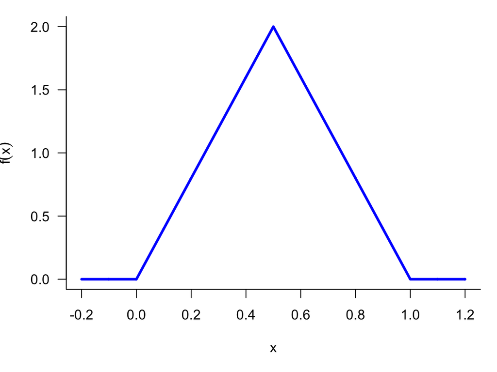

## Exemplo

Item 3 - Para encontrarmos as probabilidades dos eventos, basta integrar nas regiões correspondentes: \[P(X\leq 1/2) = \int_0 ^{1/2} f(x)dx = \int_0 ^{1/2} 4x dx = 1/2 \,. \]

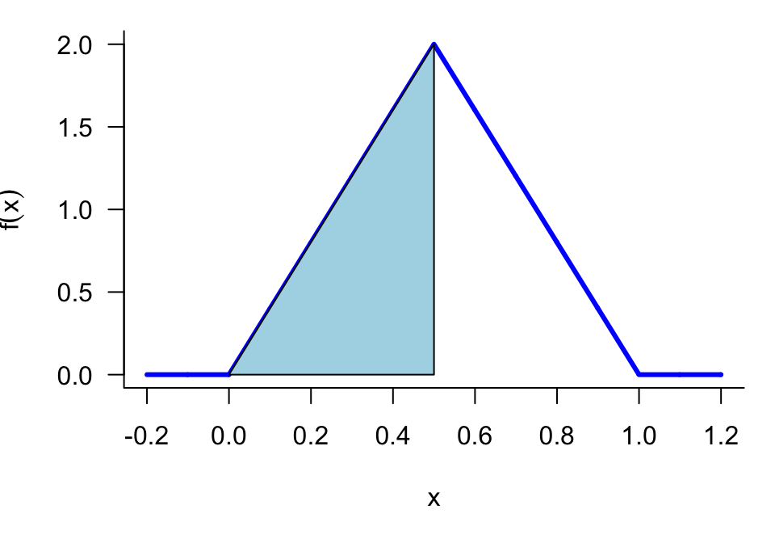

> Note que \(P(X>1/2) = 1-P(X\leq 1/2) = 1-1/2 = 1/2\).

## Exemplo

\[P(1/4 \leq X \leq 3/4) = \int_{1/4} ^{3/4} f(x)dx = \int_{1/4} ^{1/2} 4xdx + \int_{1/2} ^{3/4} 4(1-x)dx = \frac{3}{4}\,.\]

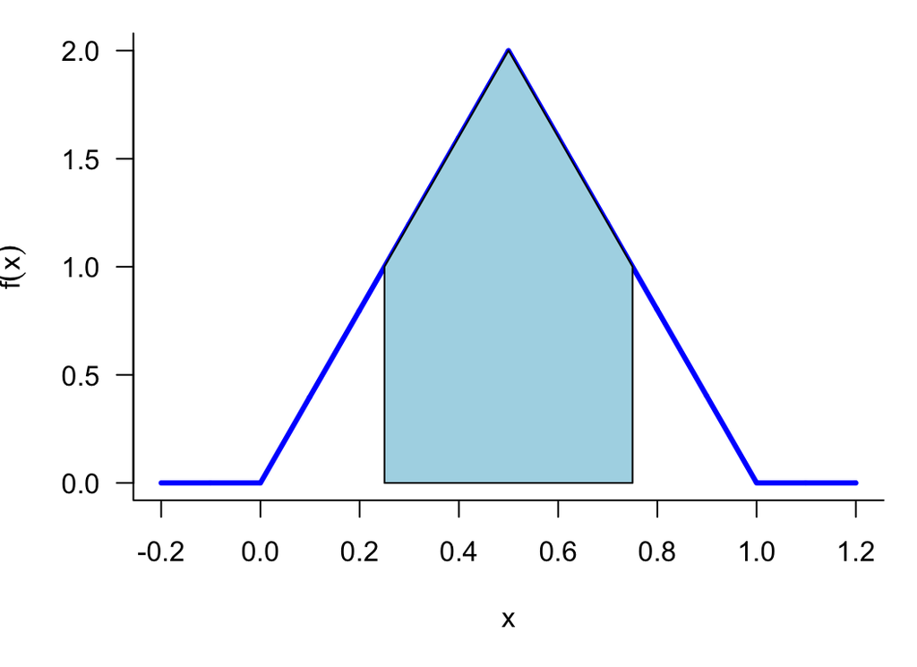

## Exemplo

Calcule a esperança, a variância e a f.d.a. da variável aleatória \(X\) com a densidade triangular em \([0,1]\).

*Fonte:* Morettin & Bussab, Estatística Básica \(5^a\) edição, pág 171.

\[ \begin{aligned} \mathbb E(X) &= \int_{-\infty}^{\infty} \!\! x f(x) dx = \int_0^{1/2} \! 4x^2dx + \int_{1/2}^{1} \! 4x(1-x)dx\\ & = \left[ \frac{4x^3}{3} \right]_0^{1/2} + \left[ \frac{2}{3} x^2(3-2x) \right]_{1/2}^{1} = \frac{1}{2} \end{aligned} \]

## Exemplo

\[ \begin{aligned} \mbox{Var}(X)& = \int_{-\infty}^{\infty} \!\! (x - \mathbb E(X))^2 f(x) dx \\ &= \int_0^{1/2} \! 4 \left(x-\frac{1}{2}\right)^2 \! xdx + \int_{1/2}^{1} \! 4 \left(x-\frac{1}{2}\right)^2 \! (1-x)dx\\ &= \left[ x^4-\frac{4}{3}x^3 + \frac{1}{2}x^2 \right]_0^{1/2} + \left[ -x^4+\frac{8}{3}^3-\frac{5}{2}x^2 +x \right]_{1/2}^{1}\\ &= \frac{1}{24} \end{aligned} \]

## Exemplo

A função de distribuição acumulada de uma variável aleatória contínua é dada por \[F(x) = \int_{-\infty}^x f(t) dt\]

> Temos que para \(x \in [0,1/2)\), \(F(x)\) é dada por \[F(x) = \int_0^x 4t dt = 2x^2\]

> Para \(x \in [1/2,1]\), a acumulada é dada por \[F(x) = \int_0^{1/2} 4t dt + \int_{1/2}^x 4(1-t)dt = -2x^2 + 4x -1\]

## Exemplo

Para valores de \(x \geq 1\), a acumulada assume valor 1. O gráfico de \(F(x)\) é dado por:

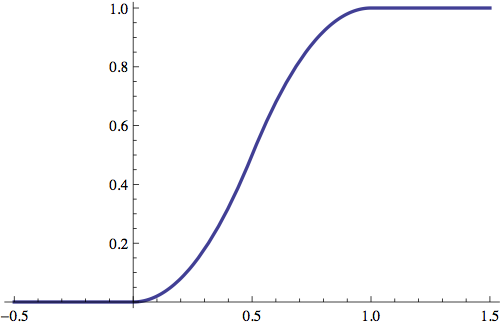

## Distribuição Uniforme

## Uniforme

- Dizemos que a v.a. \(X\) tem distribuição Uniforme no intervalo \([a,b]\), \(a<b\) se a função de densidade de probabilidade \(f_{X}\) é dada por:

\[ f_{X}(x) = \left\{ \begin{array}{ll} \frac{1}{b-a}, & a \leq x \leq b \\ 0, & \mbox{caso contrário} \\ \end{array} \right.\]

- Notação: \(X \sim U[a,b]\) ou \(X \sim U(a,b)\).
- Cálculo da função de distribuição acumulada:

\[ F_{X}(x) = \left\{ \begin{array}{ll} 0, & x < a \\ \int_{a}^{x}\frac{1}{b-a}dt=\frac{x-a}{b-a}, & a \leq x \leq b \\ 1, & x > b \\ \end{array} \right.\]

## Uniforme

Gráficos da função de densidade de probabilidade e da função de distribuição acumulada:

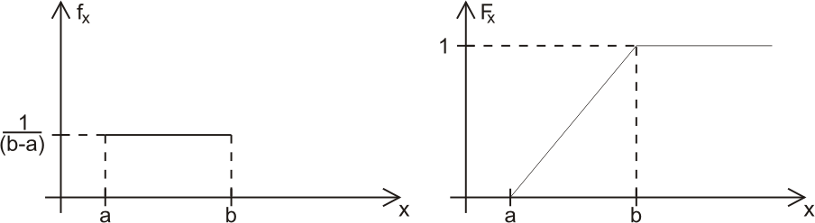

## Esperança e Variância

- Cálculo da \(\mathbb E(X)\):

\[\mathbb E(X) = \int_{a}^{b}x\frac{1}{(b-a)}dx=\frac{(b+a)}{2}\]

- Cálculo da \(Var(X)\):

\[\mathbb E(X^{2}) = \int_{a}^{b}x^{2}\frac{1}{(b-a)}dx = \frac{(a^{2}+ab+b^{2})}{3}\]

\[\begin{aligned} Var(X) & = \mathbb E(X^{2}) - [\mathbb E(X)]^{2} \\ &= \frac{(a^{2}+ab+b^{2})}{3}-\frac{(b+a)^{2}}{4}= \frac{(b-a)^{2}}{12} \end{aligned}\]

## Exemplo: peça de aço

A dureza \(H\) de uma peça de aço pode ser pensada como uma v.a. com distribuição uniforme no intervalo \([50,70]\) da escala de Rockwel. Calcule a probabilidade de que uma peça tenha dureza entre 55 e 60.

A densidade de uma \(U[50, 70]\) é dada por:

\[ f_{H}(h) = \left\{ \begin{array}{ll} \frac{1}{70-50}=\frac{1}{20}, & 50 \leq x \leq 70 \\ 0, & \mbox{caso contrário} \\ \end{array} \right.\]

Portanto, a probabilidade de uma peça ter dureza entre 55 e 60 é: \[P(55 < H < 60) = \int_{55}^{60}\frac{1}{20}dh = \frac{1}{20}(60-55) = \frac{1}{4}\,.\]

## Exemplo

Seja \(X\) uma variável aleatória distribuída uniformemente, com média 15 e variância 25/3.

- Encontre a função de densidade de \(X\).
- Qual é a probabilidade que \(X > 14\)?

## Exemplo

Lembre-se que a esperança de uma v.a. uniforme em \([a,b]\) é dada por \[\mathbb E(X) = \frac{a+b}{2},\] e sua variância por \[\mbox{Var}(X) = \frac{(b-a)^2}{12}.\]

> Temos, portanto, o seguinte sistema:

\[ \left\{ \begin{array}{lcr} \frac{a+b}{2} &=& 15 \\ \frac{(b-a)^2}{12} &=& \frac{25}{3} \\ \end{array} \right. \qquad \Longrightarrow \qquad \left\{ \begin{array}{lcr} a+b &=& 30 \\ (b-a)^2 &=& 100 \\ \end{array} \right. \]

## Exemplo

Ou simplesmente (você é capaz de dizer por que tomamos a raiz positiva apenas, neste sistema não-linear?)

\[ \left\{ \begin{array}{ccr} a + b & = & 30 \\ b - a & = & 10 \\ \end{array} \right. \]

> O sistema tem solução \(a=10\), \(b=20\), o que nos mostra que \(X \sim U[10,20]\) e

\[ f_{X}(x) = \left\{ \begin{array}{ll} \frac{1}{10}, & 10 \leq x \leq 20 \\ 0, & \mbox{caso contrário} \\ \end{array} \right.\]

Então, a probabilidade de \(X>14\) é dada por \[P(X>14) = \int_{14}^{20}\frac{1}{10}dx = \frac{(20-14)}{10} = 0.6\]

## Distribuição Exponencial

- Dizemos que uma v.a. \(X\) possui distribuição exponencial com parâmetro \(\lambda\) (\(\lambda>0\)) se a função de densidade de probabilidade \(f_{X}\) é dada por:

\[ f_{X}(x) = \left\{ \begin{array}{ll} \lambda e^{-\lambda x}, & x \geq 0 \\ 0, & \mbox{caso contrário} \\ \end{array} \right.\]

- Notação: \(X \sim exp(\lambda)\).
- Cálculo da função de distribuição acumulada:

\[ F_{X}(x) = \left\{ \begin{array}{ll} \int_{0}^{x}\lambda e^{-\lambda t}dt=1-e^{-\lambda x}, & x \geq 0 \\ 0, & \mbox{caso contrário} \\ \end{array} \right.\]

## Distribuição Exponencial

Gráficos da função de densidade de probabilidade (esquerda) e da função de distribuição acumulada (direita) de \(X \sim Exp(0.5)\):

[figure not shown]

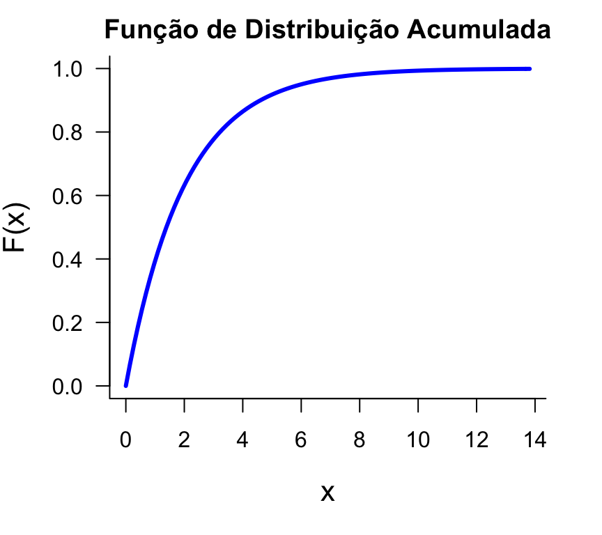

## Esperança e Variância

- Cálculo da \(\mathbb E(X)\):

\[\mathbb E(X)=\int_{0}^{\infty}x\lambda e^{-\lambda x}dx=\frac{1}{\lambda}\]

- Cálculo da \(Var(X)\):

\[\mathbb E(X^{2})=\int_{0}^{\infty}x^{2}\lambda e^{-\lambda x}dx=\frac{2}{\lambda^{2}}\]

> \[Var(X) = \mathbb E(X^{2}) - [\mathbb E(X)]^{2} = \frac{2}{\lambda^{2}} - \frac{1}{\lambda^{2}} = \frac{1}{\lambda^{2}}\]

## Exemplo: componente eletrônico

O tempo de vida, \(X\), em horas, de um componente eletrônico segue uma distribuição exponencial de tal forma que \(P(X\leq 1000) = 0.75\).

Qual é o tempo médio de vida do componente?

## Exemplo: componente eletrônico

Sabemos que se \(X \sim exp(\lambda)\), então \[F(x) = P(X \leq x) = 1-e^{-\lambda x}\] e \(\mathbb E(X) = \lambda^{-1}\).

> Basta então observarmos que

\[P(X \leq 1000) = 1 - e^{-\lambda 1000} = 0.75 \quad \Leftrightarrow \quad \lambda = \frac{\ln(4)}{1000} = 0.0013863\]

> Concluimos então que o tempo médio de vida, \(\mathbb E(X)\), é igual a \(1/0.0013863 = 721.35\) horas, e que \(75\%\) dos componentes duram 1000 horas ou menos.

## Exemplo: tubos de TV

Um antiga fábrica de tubos de TV determinou que a vida média dos tubos de sua fabricação é de \(800\) horas de uso contínuo e segue uma distribuição exponencial.

> Qual a probabilidade de que a fábrica tenha que substituir um tubo gratuitamente, se oferece uma garantia de \(300\) horas de uso?

## Exemplo: tubos de TV

\(X\): vida útil do tubo de TV.

> Como \(X\) tem distribuição exponencial com parâmetro \(\lambda\) e \(\mathbb E[X] = 800\), temos: \[\mathbb E[X] = \frac{1}{\lambda}=800 \qquad \Longrightarrow \qquad \lambda = \frac{1}{800}.\]

Então, a f.d.p. é dada por \(\displaystyle \qquad f_{X}(x) = \left\{ \begin{array}{ll} \frac{1}{800} e^{-\frac{x}{800}}, & x \geq 0 \\ 0, & \mbox{caso contrário} \\ \end{array} \right.\)

> Se \(X < 300\), a fábrica tem que substituir gratuitamente.

\[P(X<300) = \int_0^{300}\frac{1}{800}e^{-\frac{x}{800}}dx =\left[-e^{-\frac{x}{800}} \right]_0^{300}= 0.3127\,.\]

## Exemplo: produto alimentício

A f.d.p. \[ f_{X}(x) = \left\{ \begin{array}{ll} 2 e^{-2 x}, & x \geq 0 \\ 0, & \mbox{caso contrário} \\ \end{array} \right.\]

representa a distribuição do índice de acidez (\(X\)) de um determinado produto alimentício.

> O produto é consumível se este índice for menor do que \(2\).

> O setor de fiscalização apreendeu \(30\) unidades do produto. Qual a probabilidade de que pelo menos \(10\%\) da amostra seja imprópria para consumo?

## Exemplo: produto alimentício

Produto liberado para consumo se: \(P(X<2) = \int_0^22 e^{-2 x}dx= \left[-e^{-2x} \right]_0^{2}=0.98\).

> Produto não consumível com probabilidade \(1 - P(X<2) = 0.02 = p\).

> \(Y\): número de unidades impróprias para consumo na amostra de 30.

> \(Y\sim \mbox{Bin}(30, 0.02)\).

Probabilidade de que pelo menos 10% de uma amostra de 30 unidades seja imprópria: \[ \begin{aligned} P(Y \geq 3) &= 1- P(Y<3) \\ &= 1 - [P(Y=0) + P(Y=1) + P(Y=2)] \\ &= 1 - \left[\binom{30}{0}(0.02)^0(0.98)^{30} + \binom{30}{1}(0.02)^1(0.98)^{29}+\binom{30}{2}(0.02)^2(0.98)^{28} \right]\\ &= 0.022 \end{aligned} \]

## Distribuição Gama

Uma v.a. contínua \(X\) segue a distribuição gama com parâmetros \(\alpha\) e \(\lambda\) (\(\alpha>0\) e \(\lambda>0\)) se a f.d.p. de \(X\) for dada por:

\[f(x)=\frac{1}{\Gamma(\alpha)}x^{\alpha-1}\lambda^{\alpha}e^{-\lambda x}\,, x\geq0\]

A função gama é definida por: \(\Gamma(\alpha)=\int_0^{\infty}x^{\alpha-1}e^{-x}dx\).

Para qualquer inteiro positivo \(n\): \(\Gamma(n)=(n-1)!\).

Caso especial: \(\alpha=1\), temos \(X\sim Exp(\lambda)\).

Quando \(\alpha=n\), inteiro, \(X\) representa o tempo de espera até que \(n\) eventos ocorram.

## Distribuição Gama

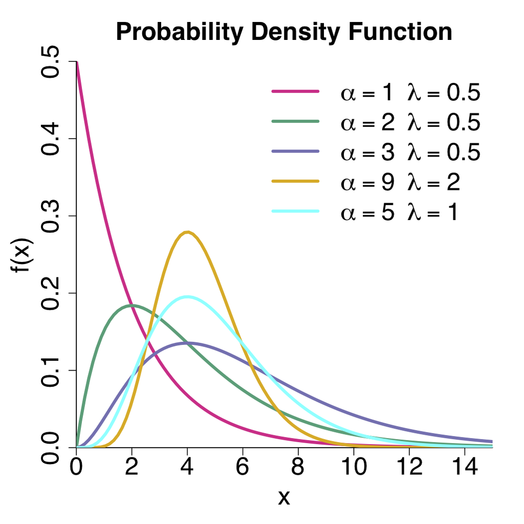

## Distribuição Gama

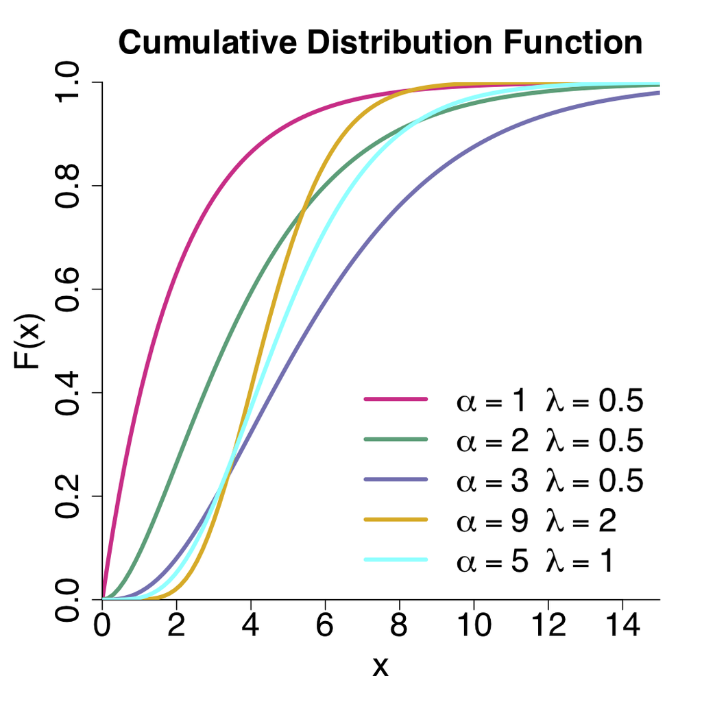

## Distribuição Gama

\(E(X)=\frac{\alpha}{\lambda}\)

\(Var(X)=\frac{\alpha}{\lambda^2}\)

Prove!

## Distribuição Beta

Uma v.a. \(X\) tem distribuição Beta com parâmetros \(\alpha\) e \(\beta\) (\(\alpha>0\), \(\beta>0\)) se sua f.d.p. for dada por:

\[f(x) = \frac{1}{B(\alpha,\beta)}x^{\alpha-1}(1-x)^{\beta-1}\,, \quad 0<x<1\]

sendo

\[B(\alpha,\beta) = \frac{\Gamma(\alpha)\Gamma(\beta)}{\Gamma(\alpha+\beta)}\]

Obs: \(X\sim Beta(\alpha=1,\beta=1)\), então \(X\sim U(0,1)\).

## Distribuição Beta

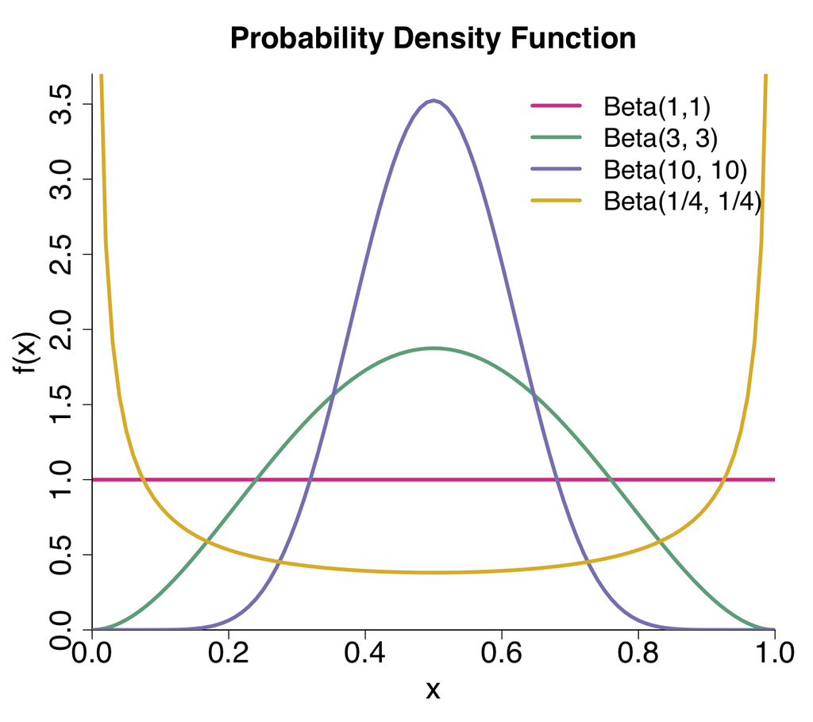

## Distribuição Beta

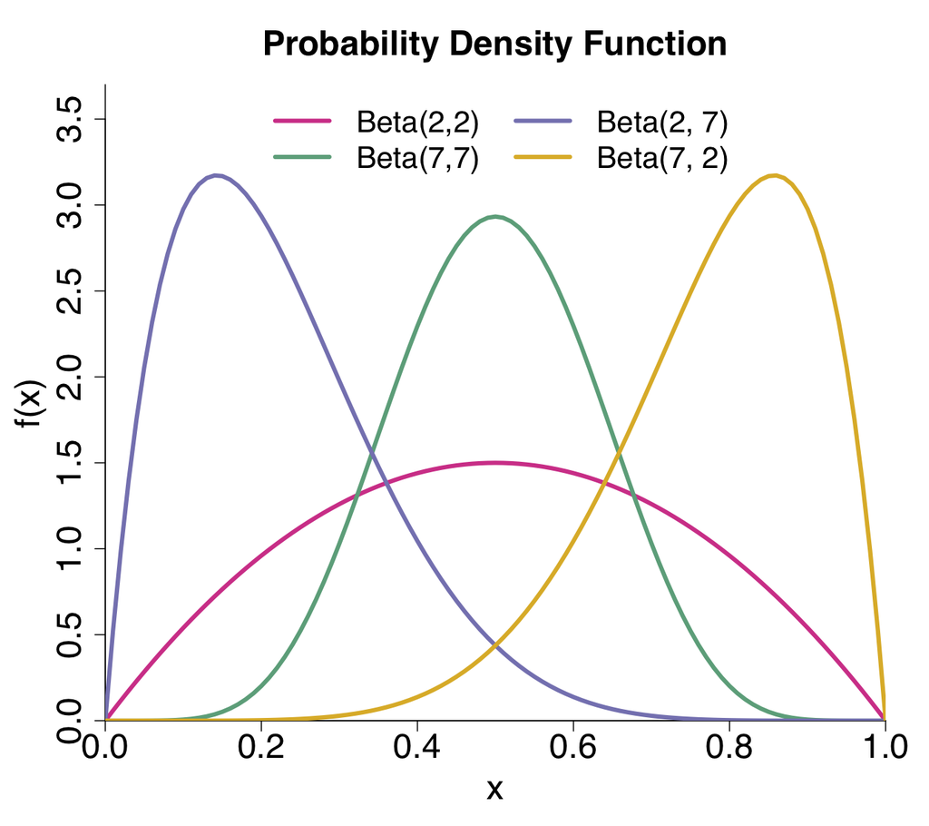

## Distribuição Beta

Momentos:

\[E(X)=\frac{\alpha}{\alpha+\beta}\]

\[E(X^k)=\frac{\Gamma(\alpha+\beta)\Gamma(\alpha+k)}{\Gamma(\alpha+\beta+k)\Gamma(\alpha)}\]

\[Var(X) = \frac{\alpha\beta}{(\alpha+\beta)^2(\alpha+\beta+1)}\]

## Leituras

- Devore: capítulo 4.
- [Ross](http://www.sciencedirect.com/science/article/pii/B9780123743886000065): seções 6.1 e 6.2.
- Magalhães: capítulo 6.

Slides produzidos pelos professores:

- Samara Kiihl
- Tatiana Benaglia
- Benilton Carvalho